# **TAREA_CURSO_R**

Visualización

Sthefanny Meliza Villa Toledo

2023-03-03

```r
# Instalar librerías requeridas
library(readr)
library(RCurl)
library(ggplot2)
library(dplyr)
library(ggpubr)
library(datasets)
library(gridExtra)
```

## R Markdown

Sthefanny Villa - `sthefanny.villa@est.ikiam.edu.ec` - Universidad Regional Amazónica IKIAM, Tena (Ecuador)

# Tarea Visualizacion

**¿Qué es una buena visualización?**

Es algo que cautiva a la audiencia y refuerza el mensaje que se desea comunicar. Para ello se debe identificar lo siguiente:

- El mensaje utilizando la visualización exploratoria.
- La mejor representación para el mensaje.
- La apariencia que mejor resalta los hallazgos.
- Mensajes adicionales apropiados.

**¿Cómo se logra una buena visualización?**

Empleando los elementos adecuados en el diseño de la visualización de datos. Estos elementos fueron compilados y establecidos por Leland Wilkinson en su libro “The grammar of graphics: statistcs and computing”. Se tiene dos tipos de visualizaciones concatenadas: **Visualización de análisis - visualización de presentación**

# Instrucciones

Use un documento tipo *.Rmd* o *.qmd* y genere un informe *html.* Estos dos documentos (Rmd y html) guardelos con control de cambios en un repositorio de GitHub y **pegue solamente el enlace del repositorio** en esta entrega. La entrega debe contener los códigos para obtener las siguientes figuras:

## Data

Son datos preinstalados en R.

```r
## **ToothGrowth:** contiene la longitud de los odontoblastos (células responsables del crecimiento dental) en 60 cobayos. Cada animal recibió uno de tres niveles de dosis de vitamina C (0.5, 1 y 2 mg/día) por uno de dos métodos de entrega, jugo de naranja o ácido ascórbico (una forma de vitamina C y codificada como VC). Tiene 60 observaciones y 3 variables: len (longitud del diente), supp (tipo de suplemento) y dose (dosis de vitamina C).
data("ToothGrowth")
head(ToothGrowth, n=4)
```

```
##    len supp dose
## 1  4.2   VC  0.5
## 2 11.5   VC  0.5
## 3  7.3   VC  0.5
## 4  5.8   VC  0.5
```

```r
##**mtcars:** contiene el consumo de combustible y 10 aspectos del diseño y rendimiento del automóvil para 32 automóviles (modelos 1973-74). Tiene 32 observaciones y 11 variables numéricas: mpg (millas por galón), cyl (número de cilindros), disp (desplazamiento del motor), hp (caballos de fuerza), drat (relación del eje trasero), wt (peso), qsec (tiempo en el cuarto de milla), vs (forma del motor), am (transmisión manual o automática), gear (número de marchas) y carb (número de carburadores).

data("mtcars")
head(mtcars, n=4)
```

```
##                 mpg cyl disp  hp drat    wt  qsec vs am gear carb
## Mazda RX4      21.0   6  160 110 3.90 2.620 16.46  0  1    4    4
## Mazda RX4 Wag  21.0   6  160 110 3.90 2.875 17.02  0  1    4    4
## Datsun 710     22.8   4  108  93 3.85 2.320 18.61  1  1    4    1
## Hornet 4 Drive 21.4   6  258 110 3.08 3.215 19.44  1  0    3    1
```

```r
##Diamonds: contiene las mediciones sobre 10 variables diferentes para 53.940 diamantes. Tiene 53.940 observaciones y 10 variables: price(precio en dólares estadounidenses), carat(peso del diamante en quilates), cut(calidad del corte: Fair, Good, Very Good, Premium o Ideal), color(color del diamante desde J(peor) hasta D(mejor)), clarity(claridad desde I1(peor) hasta IF(mejor)), x(longitud en mm.), y(ancho en mm.), z(profundidad en mm.), depth(profundidad total porcentual = z / media(x,y)), table(ancho superior relativo al punto más ancho).)

data("diamonds")
head(diamonds, n=4)
```

```
## # A tibble: 4 × 10
##   carat cut     color clarity depth table price     x     y     z
##   <dbl> <ord>   <ord> <ord>   <dbl> <dbl> <int> <dbl> <dbl> <dbl>
## 1  0.23 Ideal   E     SI2      61.5    55   326  3.95  3.98  2.43
## 2  0.21 Premium E     SI1      59.8    61   326  3.89  3.84  2.31
## 3  0.23 Good    E     VS1      56.9    65   327  4.05  4.07  2.31
## 4  0.29 Premium I     VS2      62.4    58   334  4.2   4.23  2.63
```

## 1. Réplica de la figura compuesta.

```r
## Cambio en cy1 a variable categorica y no numerica
data("mtcars")
mtcars$name  = rownames(mtcars)
mtcars$cyl  = as.factor(mtcars$cyl)

head(mtcars[, c("name", "wt", "mpg", "cyl")])
```

[output not shown]

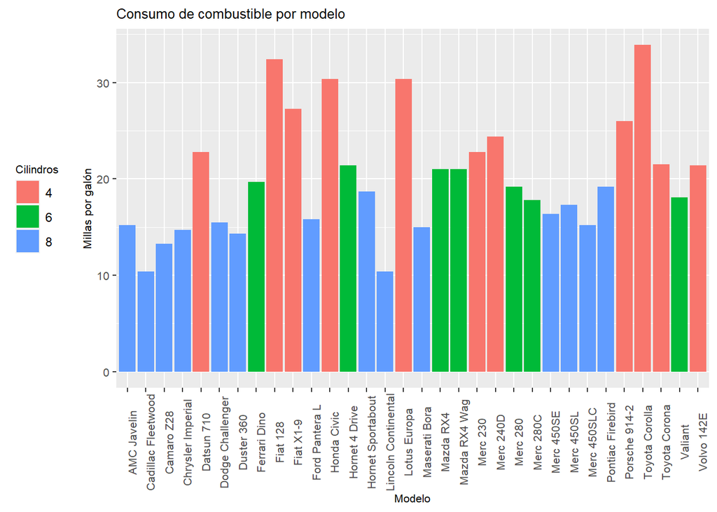

```r
#Barplot por registro
## se definen los datos y las variables + se crea las barras +  se mueve la leyenda a la izquierda + se rota los nombres del eje x + se pone el título
cars1<-ggplot(mtcars, aes(x = name, y = mpg, fill = cyl)) +
  geom_bar(stat = "identity", position = "dodge") +
  theme(legend.position = "left",
        axis.text.x = element_text(angle = 90)) +
  labs(title = "Consumo de combustible por modelo",
       x = "Modelo", # se agrega el nombre del eje x
       y = "Millas por galón", # se agrega el nombre del eje y
       fill = "Cilindros")+ # se agrega el nombre de la leyenda
      theme(axis.text = element_text(size = 8),
            axis.title = element_text(size = 8),
            title = element_text(size = 8))
cars1
```

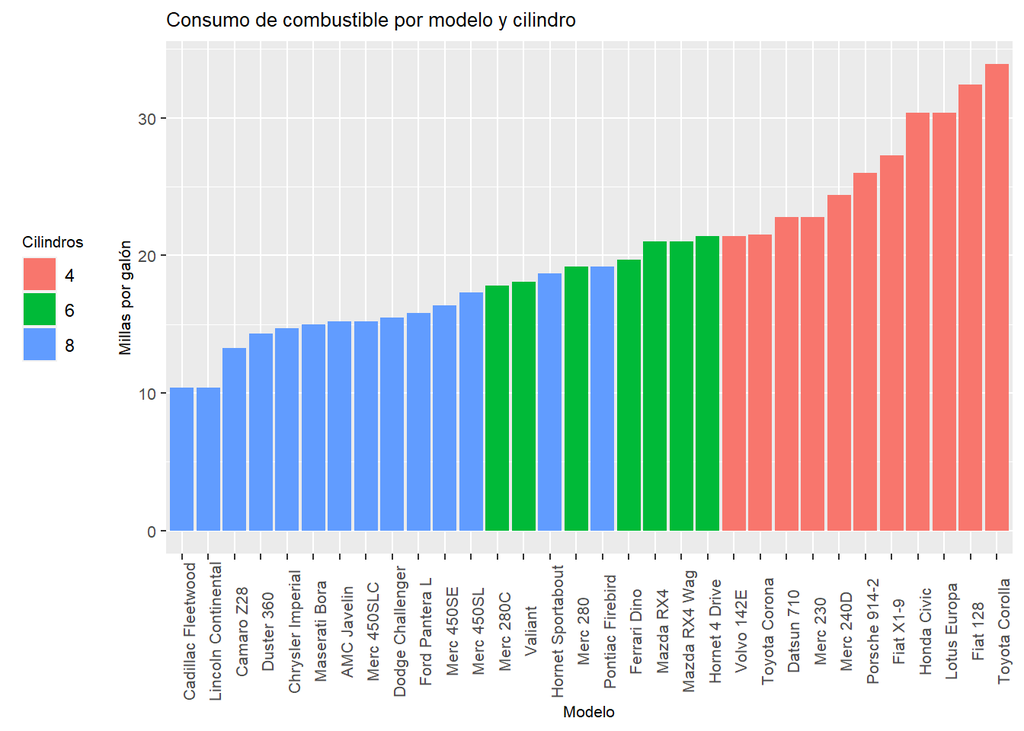

```r
cars2<-ggplot(mtcars, aes(x = reorder(name, mpg), y = mpg, fill = cyl)) +
  geom_bar(stat = "identity", position = "dodge") +
  theme(legend.position = "left",
        axis.text.x = element_text(angle = 90)) +
  labs(title = "Consumo de combustible por modelo y cilindro", x = "Modelo", y = "Millas por galón",
       fill = "Cilindros")+
      theme(axis.text = element_text(size = 8),
            axis.title = element_text(size = 8),
            title = element_text(size = 8))
cars2
```

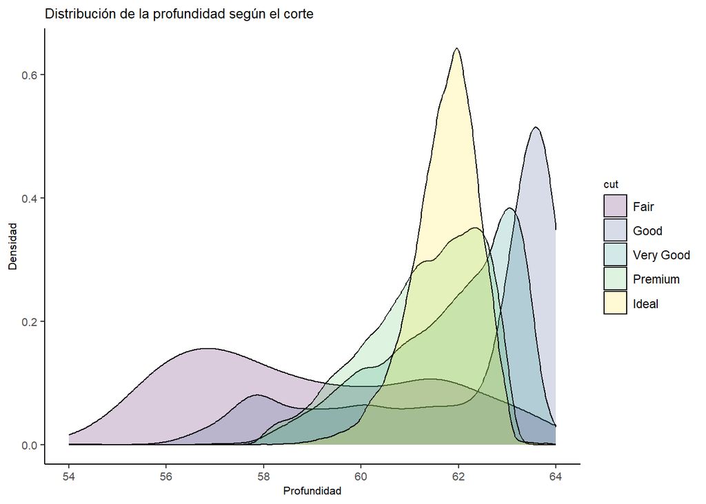

```r
##Densidades
data("diamonds")
dens<- ggplot(diamonds, aes(x = depth, fill = cut)) + geom_density(alpha = 0.2) + theme(legend.position = "left",
        axis.text.x = element_text(angle = 90)) +
  labs(title = "Distribución de la profundidad según el corte", x = "Profundidad", y = "Densidad") +
  theme_classic() +
  xlim(54,64) +
  theme(axis.text = element_text(size = 8),
            axis.title = element_text(size = 8),
            title = element_text(size = 8))

dens
```

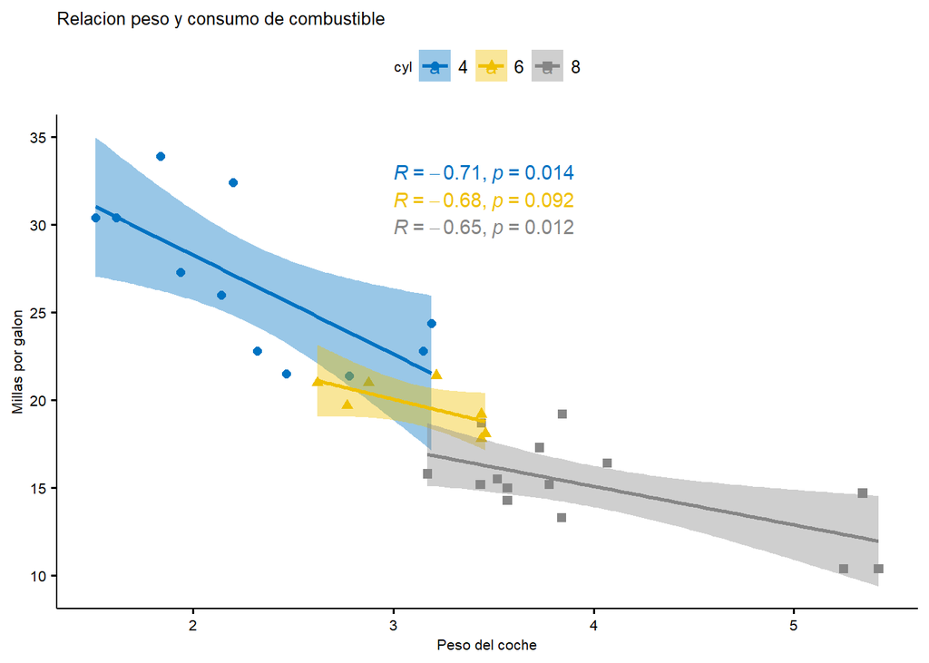

```r
## Gráfica de dispersión

dispercion <- ggscatter(mtcars, x = "wt", y = "mpg", add = "reg.line", conf.int = TRUE, color = "cyl", palette = "jco", shape = "cyl") +
  stat_cor(aes(color = cyl), label.x = 3) +
  labs(title= "Relacion peso y consumo de combustible",x = "Peso del coche", y = "Millas por galon") +
  theme(axis.text = element_text(size = 8),
            axis.title = element_text(size = 8),
            title = element_text(size = 8))
dispercion
```

## Gráfico de puntos

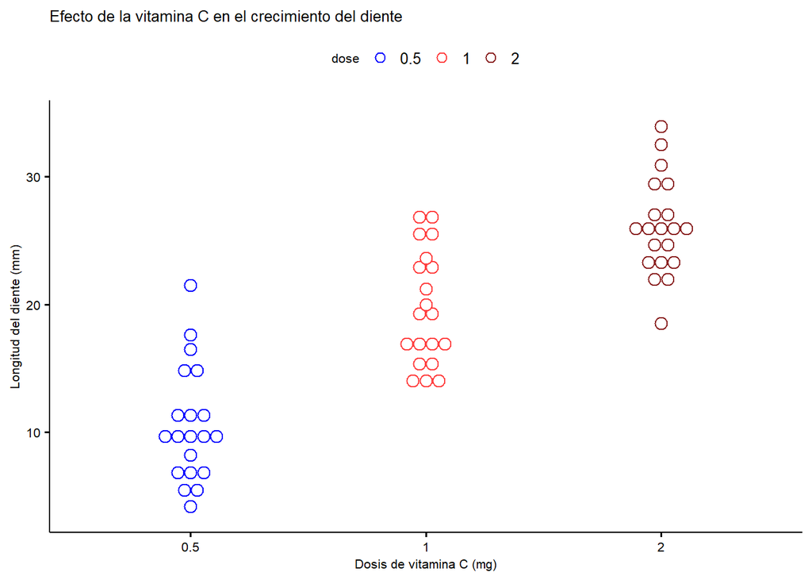

```r
Puntos <- ggdotplot(ToothGrowth, x = "dose", y = "len",
                color = "dose",
                palette = "mpg",
                binwidth = 1) +
      labs(title = "Efecto de la vitamina C en el crecimiento del diente", x = "Dosis de vitamina C (mg)", y = "Longitud del diente (mm)")+
    scale_color_manual(values = c( "blue1","brown1", "brown4")) +
            theme(axis.text = element_text(size = 8),
            axis.title = element_text(size = 8),
            title = element_text(size = 8))
Puntos
```

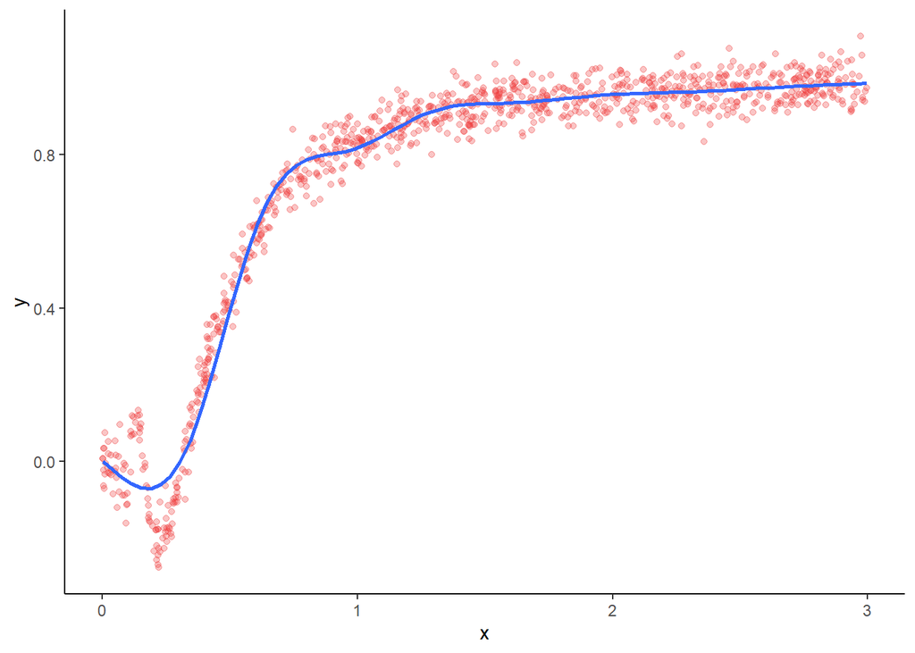

```r
## Gráfica zoom
set.seed(42)   #semilla
n <- 1000      #tamaño
x <- runif(n) * 3  # Valores x, y
# Función no lineal de x, mas ruido normal
y <- x * sin(1/x) + rnorm(n) / 25
df <- data.frame(x = x, y = y)
zoom1 <- ggplot(df, aes(x, y)) + geom_point(alpha = 0.3, col = "brown2") +
  geom_smooth(se = FALSE) + theme_classic()
#se crea la segunda grafica con limites
zoom2 <- ggplot(df, aes(x, y)) + geom_point(alpha = 0.3, col = "lightblue2") + geom_smooth(se = FALSE) +
  scale_x_continuous(limits = c(0, 0.5)) +
  scale_y_continuous(limits = c(-0.5, 0.5)) +
  labs(x = NULL, y = NULL) + theme_classic()
zoom1
```

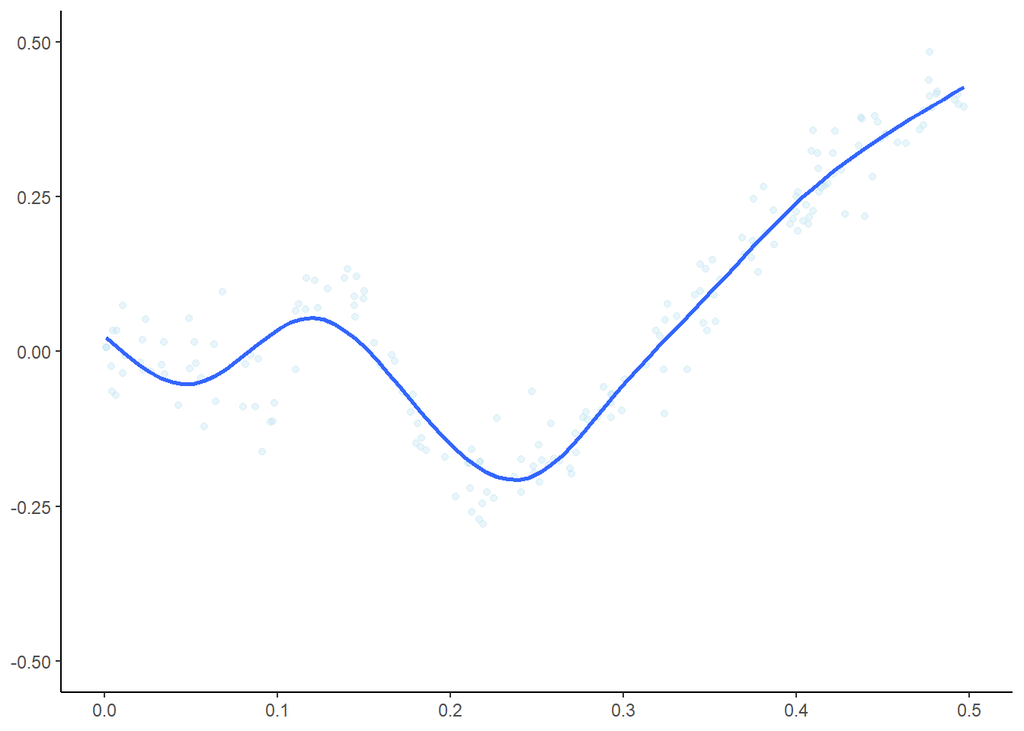

```r
zoom2
```

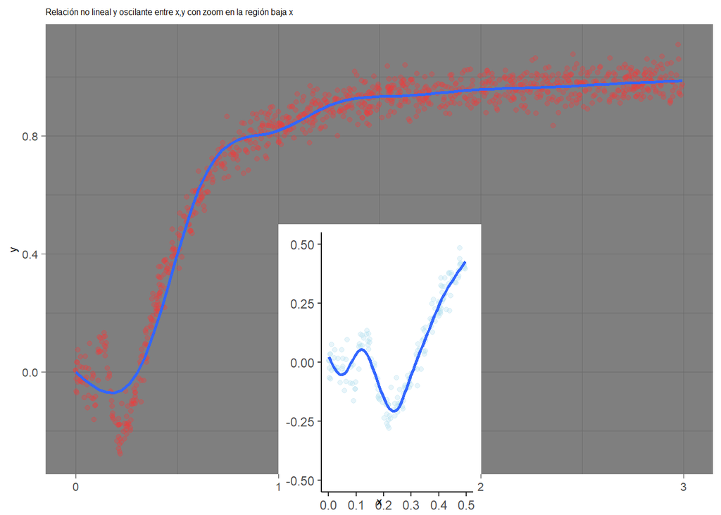

```r
# Se combinan las dos gráficas usando annotation_custom()
Z <- zoom1 + annotation_custom(ggplotGrob(zoom2), xmin = 1, xmax = 2, ymin = -0.5, ymax = 0.5) +
  labs(title = "Relación no lineal y oscilante entre x,y con zoom en la región baja x") + theme_dark() + theme(axis.text = element_text(size = 8),
            axis.title = element_text(size = 8),
            title = element_text(size = 5))
Z
```

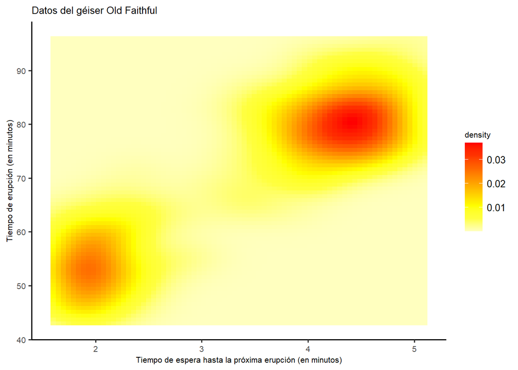

```r
## Grafica de calor
Calor <- ggplot(faithfuld, aes(eruptions, waiting)) +
  geom_raster(aes(fill = density))+
  theme_classic2()+
  scale_fill_gradientn(colours = heat.colors(8, rev = TRUE), na.value = "lightblue1") +
  labs(title = "Datos del géiser Old Faithful", x = "Tiempo de espera hasta la próxima erupción (en minutos)", y = "Tiempo de erupción (en minutos)", fill = "density")+
            theme(axis.text = element_text(size = 8),
            axis.title = element_text(size = 8),
            title = element_text(size = 8))
Calor
```

[figure not shown]

```r
##Graficas Unidas
Completo =
  ggarrange(cars2, ggarrange(dens,ggarrange(Z, Puntos,dispercion, Calor, ncol = 2, nrow = 2,
                                labels = c("B", "C", "D", "E")),ncol = 2,
                             labels = "F"), labels = "A", nrow = 2, common.legend = TRUE) +
theme(axis.text = element_text(size = 6),
            axis.title = element_text(size = 6),
            title = element_text(size = 6))
Completo
```

## 2. Réplica de la figura embebida

Datos “Gapminder”, que es un conjunto de datos ampliamente utilizado en la enseñanza y la investigación de la ciencia de datos, tiene informacion sobre la expectativa de vida, la población y el ingreso per cápita de diferentes países del mundo, entre 1952 y 2007. El conjunto de datos incluye información sobre 142 países diferentes. Gapminder. (2008). Gapminder World 2008 (v. 1.0) [Data set]. https://www.gapminder.org/data/

```r
library(dplyr)
library(ggplot2)
library(grid)
library(gridExtra)
library(ggrepel)
```

```r
# Para cargar la data, lo que deseamos visualizar
ruta <- "https://raw.githubusercontent.com/martintinch0/CienciaDeDatosParaCuriosos/master/data/gapminder.csv"
df_gapminder <- read.table(file = ruta, sep=';', header = TRUE, stringsAsFactors = FALSE)
```

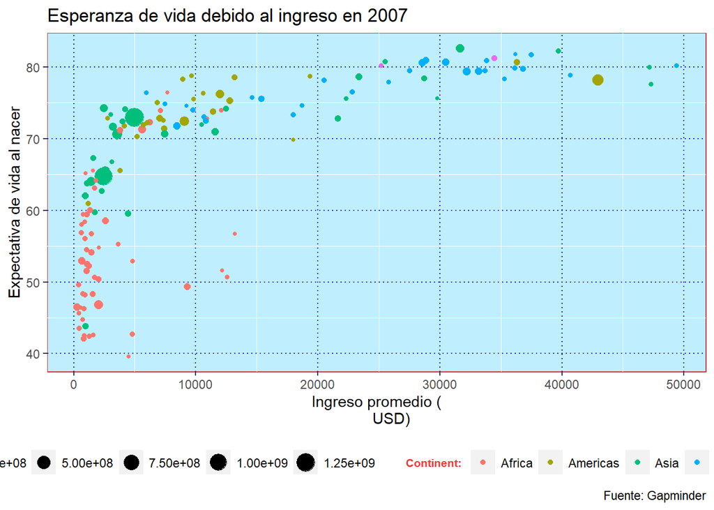

```r
# Grafico con todos los paises
dfp1 <- df_gapminder %>%
  filter(year == 2007) %>%
  ggplot(aes(x = gdpPercap, y = lifeExp, size = pop, color = continent)) +
  geom_point() +
  labs(x = "Ingreso promedio (
       USD)", y = "Expectativa de vida al nacer", title="Esperanza de vida debido al ingreso en 2007",
       caption="Fuente: Gapminder",
       color="Continent: ") +
  theme(legend.position="bottom",
        legend.title = element_text(face = "bold", color = "brown2", size= 8),
        panel.background = element_rect(fill = "lightblue1", colour = "brown3"),
        panel.grid.major = element_line(colour = "blue", linetype = "dotted"))
dfp1
```

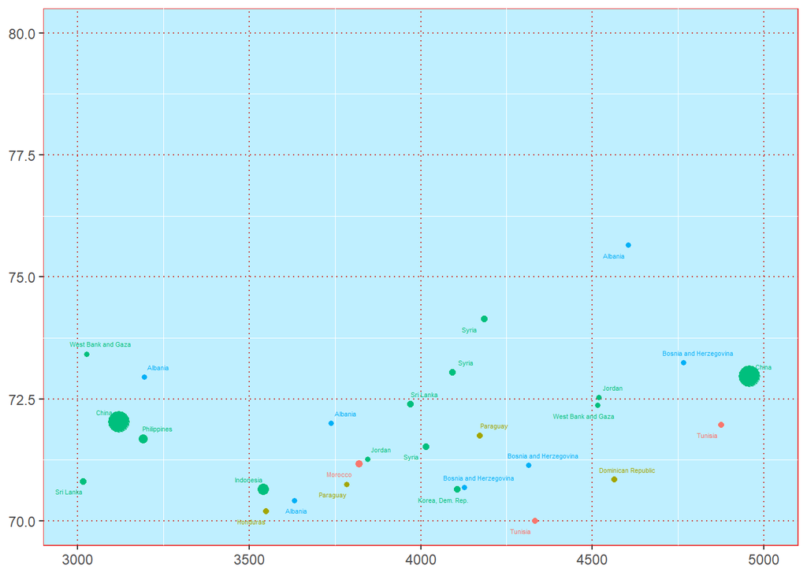

```r
#grafico de algunos paises
dfp2 = ggplot(df_gapminder, aes(x = gdpPercap, y = lifeExp,
             size=pop, color=continent)) +
  geom_point() +
  geom_text_repel(aes(label=country), size = 1.5) +
  scale_x_continuous(limits = c(3000, 5000)) +
  scale_y_continuous(limits = c(70, 80)) +
  guides(size=FALSE) +
  theme(legend.position = "null",
        axis.title = element_blank(),
        legend.title = element_text(face = "bold", color = "black", size= 8),
        panel.background = element_rect(fill = "lightblue1", colour = "brown2"),
        panel.grid.major = element_line(colour = "brown3", linetype = "dotted"))
dfp2
```

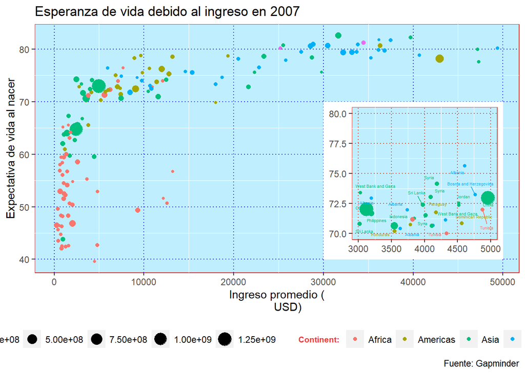

```r
embeb = dfp1 + annotation_custom(ggplotGrob(dfp2),
                        xmin = 30000, xmax = 50000,
                        ymin = 40, ymax = 70)
embeb
```